# Data on Bigtfoot/Sasquatch Sightings

### Description:

- The files used are taken from Timothy Renner's datasets at: https://data.world/timothyrenner/bfro-sightings-data
- The data in the files was scraped from here: http://www.bfro.net/news/google_earth.asp
- The analysis of the data will not be very advanced; this is mostly an exercise in using Jupyter Notebook and Python data science libraries.

```python
import matplotlib as mpl
import matplotlib.pyplot as plt
import pandas as pd
import pyplot_themes as themes
import seaborn as sns
from seaborn import palplot
import numpy as np
import mplcyberpunk


# Setting up the data by assigning it to dataframes.

location = pd.read_csv("bfro_locations.csv")

reports = pd.read_json("bfro_reports.json", lines = True)
```

## Bigfoot Sightings by State

```python
reportsDF = pd.DataFrame(reports)


# There are a lot of null values here, but every report has a STATE and YEAR value.

reports_by_stateDF = reportsDF.groupby(['STATE']).count()

# Dropping columns I don't need for the bar graph

reports_by_stateDF = reports_by_stateDF.drop(['SEASON', 'COUNTY', 'NEAREST_TOWN',
                                             'NEAREST_ROAD', 'OBSERVED', 'ALSO_NOTICED',
                                             'OTHER_WITNESSES', 'OTHER_STORIES', 'TIME_AND_CONDITIONS',
                                             'ENVIRONMENT', 'REPORT_NUMBER', 'REPORT_CLASS', 'LOCATION_DETAILS',
                                             'MONTH', 'DATE', 'A_&_G_References'], axis = 1)
```

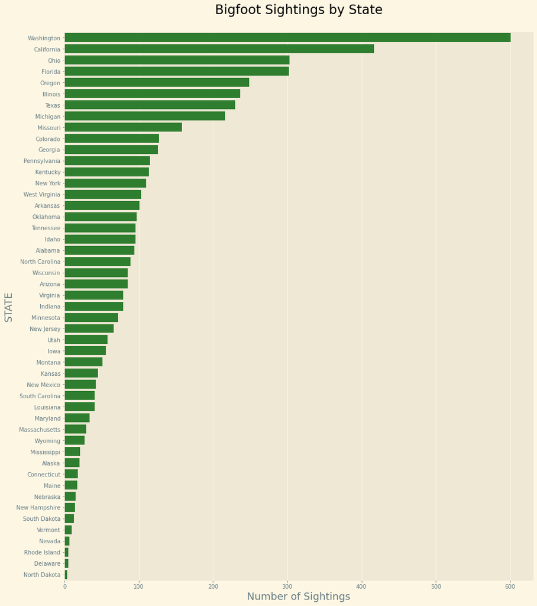

```python
# Using numpy and seaborn here since the instructions asked for examples of these libraries
# (I think it would be more efficient to just work with the DataFrame)

themes.theme_solarized_light2()
plt.rcParams["figure.figsize"] = (15,18)

statesArr = reports_by_stateDF.index.to_numpy()
sightingsArr = reports_by_stateDF.to_numpy()

sightingsArr = sightingsArr.reshape(49,)

newDF = pd.DataFrame(data = [statesArr, sightingsArr]).T
newDF = newDF.sort_values(1, ascending = False) # Sorting by sightings number


barGraph = sns.barplot(x = 1, y = 0, data = newDF, color = 'forestgreen')

barGraph.set_ylabel(ylabel = "STATE", fontsize = 18)
barGraph.set_xlabel(xlabel = "Number of Sightings", fontsize = 18)
barGraph.set_title("Bigfoot Sightings by State\n", fontsize = 23)
```

### Explanation of Code

1. Data read from a json-formatted file (bfro_reports.json)
2. The data is turned into a Pandas DataFrame
3. Unneeded columns are dropped from the DataFrame
4. The data-of-interest is converted into NumPy arrays (to show that I know how to use NumPy arrays)
5. The NumPy arrays are converted into a DataFrame and sorted
6. A bar graph is created with Seaborn using the DataFrame

### Discussion of Data

#### Data taken from: bfro_reports.json

## Bigfoot Sightings by Date

```python
locationsDF = location

print("Unfortunately, the timestamp data is actually in object format:\n")
print(locationsDF.dtypes)
print("\nI tried converting the to the datetime datatype, but there are many years covered by this data.")
print("For that reason, I will only leave the year in the timestamp column and convert that to an integer.\n")

#====================== The 'timestamp' column conversions ====================================================

# Slicing off everything except the year
locationsDF['timestamp'] = locationsDF['timestamp'].str.slice(start = 0, stop = 4)

# Renaming the 'timestamp' column to 'year'
locationsDF = locationsDF.rename(columns = {'timestamp' : 'year'})

# Converting to int
locationsDF['year'] = pd.to_numeric(locationsDF['year'])

#===============================================================================================================

print("The timestamp column is now named \"year\" and has a datatype of int64.\n")
print(locationsDF.dtypes)
```

```
Unfortunately, the timestamp data is actually in object format:

number              int64
title              object
classification     object
timestamp          object
latitude          float64
longitude         float64
dtype: object

I tried converting the to the datetime datatype, but there are many years covered by this data.
For that reason, I will only leave the year in the timestamp column and convert that to an integer.

The timestamp column is now named "year" and has a datatype of int64.

number              int64
title              object
classification     object
year                int64
latitude          float64
longitude         float64
dtype: object
```

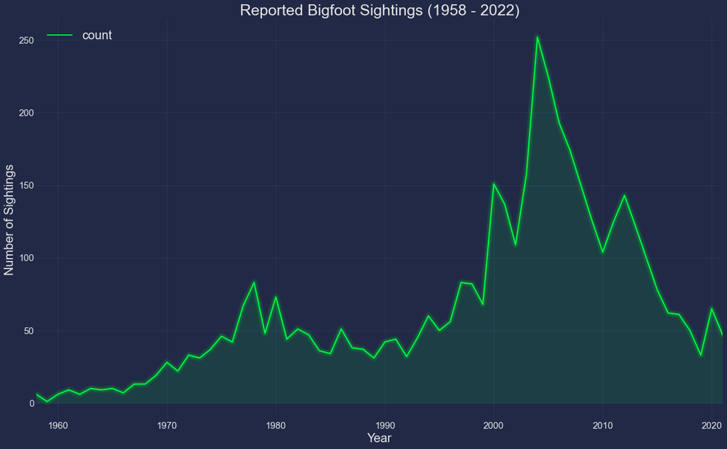

```python
plt.style.use("cyberpunk")
plt.rcParams["figure.figsize"] = (20,12) # resizing

# Creating a dataframe of year of sighting, classification of sighting
year_classDF = locationsDF.groupby(['year', 'classification']).size().reset_index(name = 'count')

# There's an entry from 2053 - I'm just going to slice that one off...
year_classDF = year_classDF[:-1]
#year_classDF = year_classDF.set_index('year')

# Making the line green to make it reminiscent of trees
year_classDF.pivot_table('count', index = 'year',aggfunc = 'sum').plot(color = '#00ff41')

plt.tick_params(axis = 'both', labelsize = 15)
plt.xlim(1958, 2021)

plt.ylabel('Number of Sightings', fontsize = 20)
plt.xlabel('Year', fontsize = 20)
plt.title('Reported Bigfoot Sightings (1958 - 2022)', fontsize = 25)
plt.legend(loc = 'upper left', prop = {'size': 20})

mplcyberpunk.make_lines_glow()
mplcyberpunk.add_underglow()
```

### Explanation of Code

1. Data is read from a csv file (bfro_locations.csv) and put into a DataFrame
2. The data for dates is converted into integer format (where the integer represents the year of the sighting)
3. A pivot table and aggregate function: sum are used to plot the total sightings reported each year.

### Discussion of Data

#### Data taken from: bfro_locations.csv

## Bigfoot Sightings by Classification

```python
# Changing the index to year should make this easier
year_classDF = year_classDF.set_index('year')
```

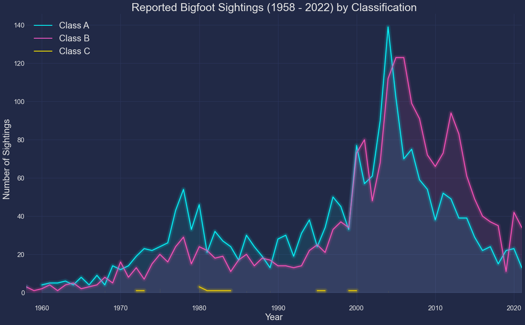

```python
year_classDF.pivot_table('count', index = 'year', columns = 'classification', aggfunc = 'sum').plot()

plt.tick_params(axis = 'both', labelsize = 15)
plt.xlim(1958, 2021)

plt.ylabel('Number of Sightings', fontsize = 20)
plt.xlabel('Year', fontsize = 20)
plt.title('Reported Bigfoot Sightings (1958 - 2022) by Classification', fontsize = 25)
plt.legend(loc = 'upper left', prop = {'size': 20})

mplcyberpunk.make_lines_glow()
mplcyberpunk.add_underglow()
```

### What do the classifications mean?

From The Bigfoot Field Researchers Organization website:

### Class A

#### Class A reports involve clear sightings in circumstances where misinterpretation or misidentification of other animals can be ruled out with greater confidence. For example, there are several footprint cases that are very well documented. These are considered Class A reports, because misidentification of common animals can be confidently ruled out, thus the potential for misinterpretation is very low.

### Class B

#### Incidents where a possible sasquatch was observed at a great distance or in poor lighting conditions and incidents in any other circumstance that did not afford a clear view of the subject are considered Class B reports. For example, credible reports where nothing was seen but distinct and characteristic sounds of sasquatches were heard are always considered Class B reports and never Class A, even in the most compelling "sound-only" cases. This is because the lack of a visual element raises a much greater potential for a misidentification of the sounds.

### Class C

#### Most second-hand reports, and any third-hand reports, or stories with an untraceable sources, are considered Class C, because of the high potential for inaccuracy. Those reports are kept in BFRO archives but are very rarely listed publicly in this database. The exceptions are for published, or locally documented incidents from before 1958 (before the word "Bigfoot" entered the American vocabulary), and sightings mentioned in non-tabloid newspapers or magazines.

#### Source: https://www.bfro.net/gdb/classify.asp

### Explanation of Code

1. A pivot table is used to set "year" as the index and aggfunc: sum is used to sum each classification type
2. The plot is formatted for readability

### Discussion of Data

It is interesting that most of the reports are Class A until the mid-2000's where Class B becomes the dominant report type. Is that when people started going into the deep forest less? Did the Sasquatches get better at hiding? Did the 2008 subprime mortgage crisis cause the creatures to be more skeptical of humans?

I don't think I can reasonably draw profound conclusions from this data analysis. All I can say is that Class B becomes the dominant classification after the mid-2000s in the BFRO database.

## Sources

bfro_locations.csv, bfro_reports:

https://data.world/timothyrenner/bfro-sightings-data

BFRO Website:

https://www.bfro.net/